# Credit Card Users Churn Prediction

Attrition Flag vs Customer Age

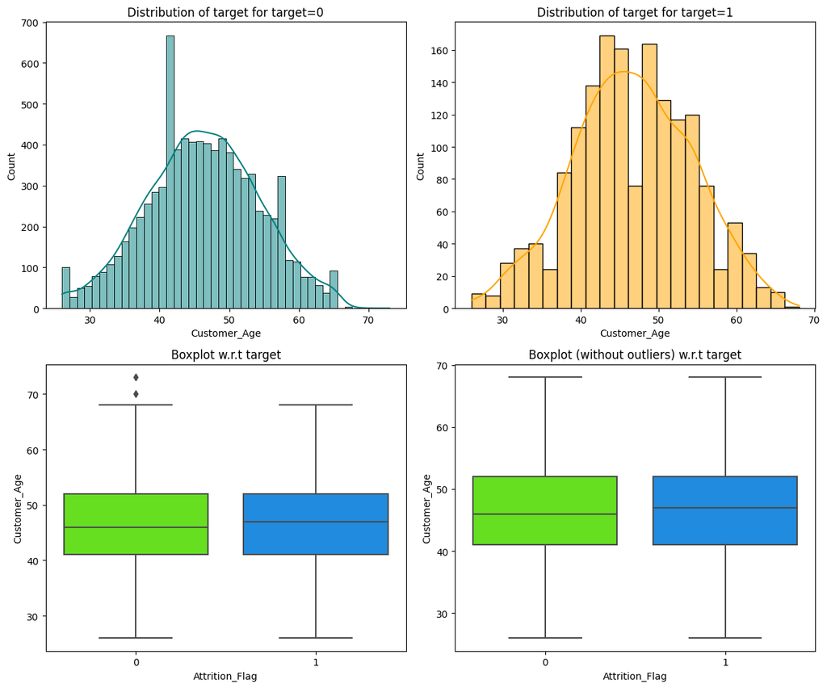

```python
distribution_plot_wrt_target(data, "Customer_Age", "Attrition_Flag")
```

Attrition Flag vs Total Trans Ct

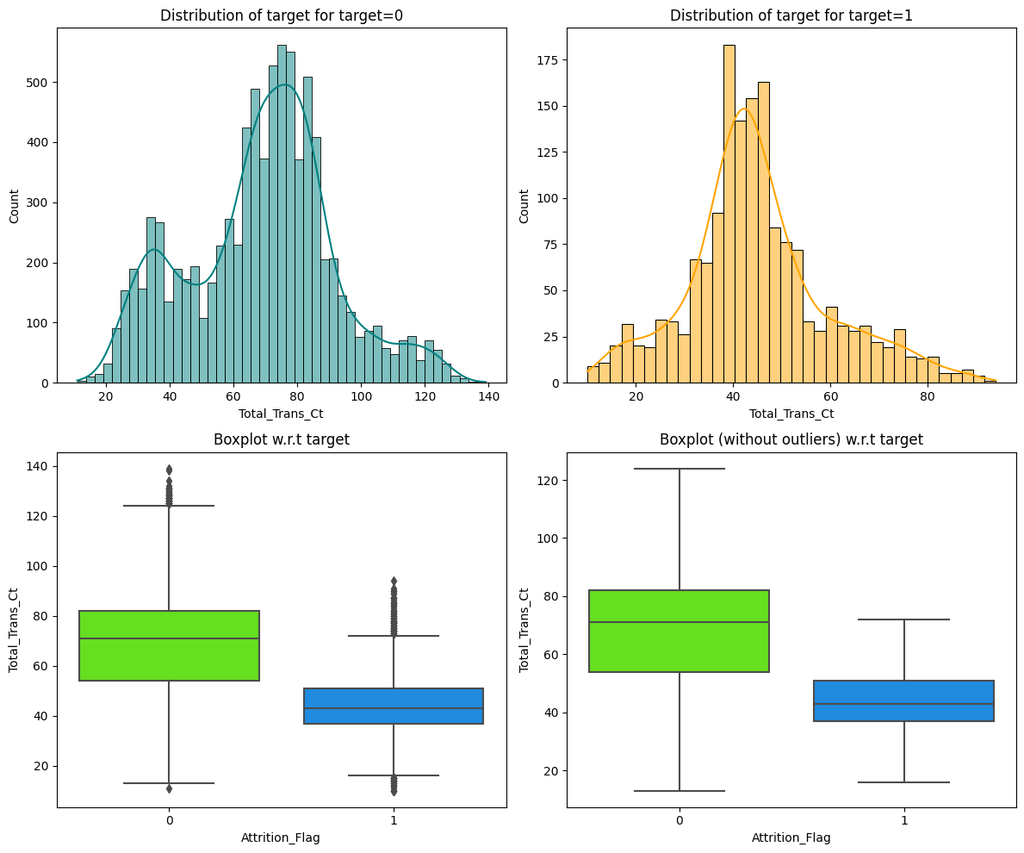

```python
distribution_plot_wrt_target(data, "Total_Trans_Ct", "Attrition_Flag")
```

Users with higher transaction count are less likely to attrition

Attrition Flag vs Total Trans Amt

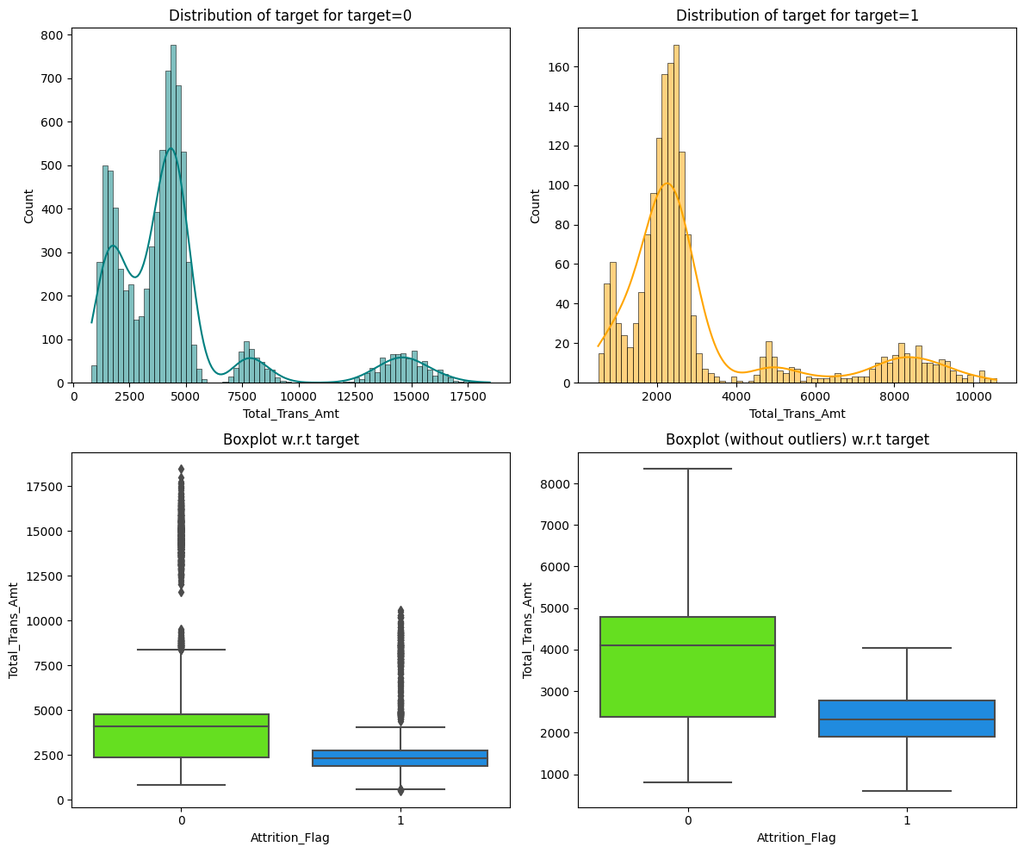

```python
distribution_plot_wrt_target(data, "Total_Trans_Amt", "Attrition_Flag")
```

Higher transaction amount means less likely to attrition

Attrition Flag vs Total_Ct_Chng_Q4_Q1

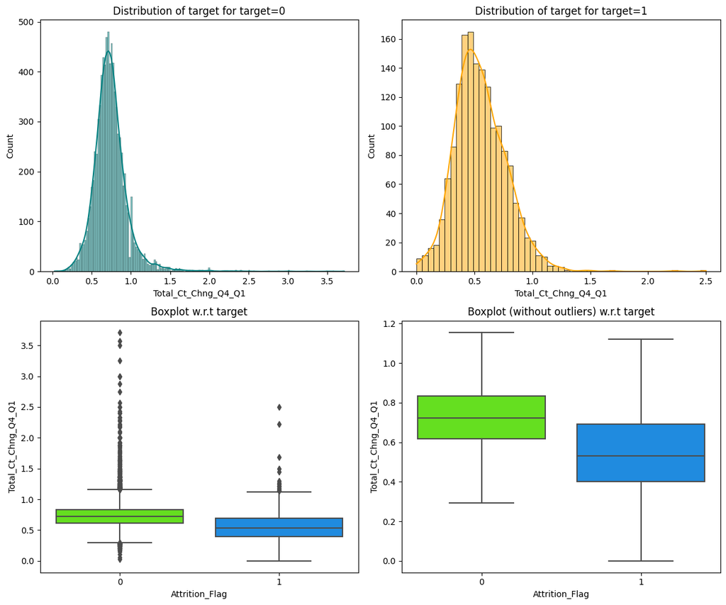

```python
distribution_plot_wrt_target(data, "Total_Ct_Chng_Q4_Q1", "Attrition_Flag")
```

Attrition Flag vs Avg_Utilization_Ratio

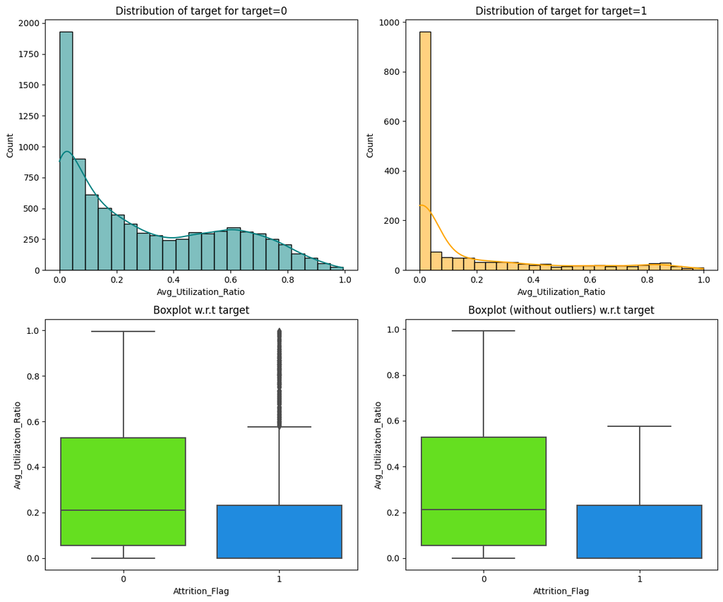

```python
distribution_plot_wrt_target(data, "Avg_Utilization_Ratio", "Attrition_Flag")
```

Attrition Flag vs Months_on_book

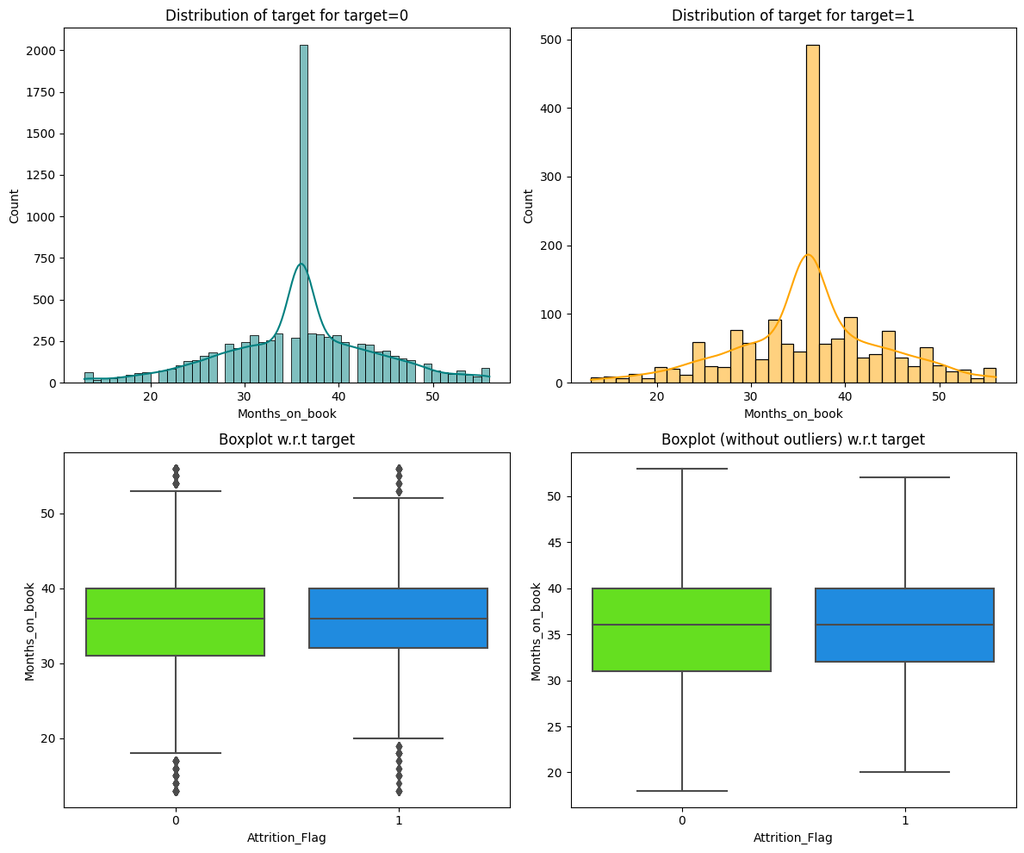

```python
distribution_plot_wrt_target(data, "Months_on_book", "Attrition_Flag")
```

For some reaon, around 35 months, the customer either closes their account or keeps it. Highly eccentric

Attrition Flag vs Total_Revolving_Bal

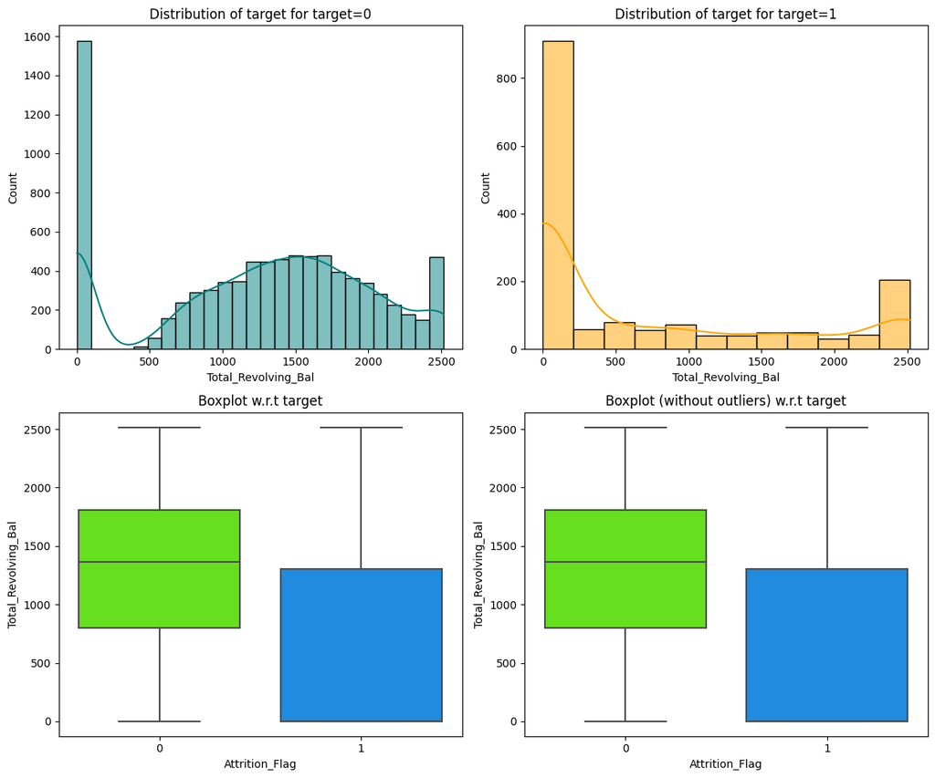

```python
distribution_plot_wrt_target(data, "Total_Revolving_Bal", "Attrition_Flag")
```

Attrition Flag vs Avg_Open_To_Buy

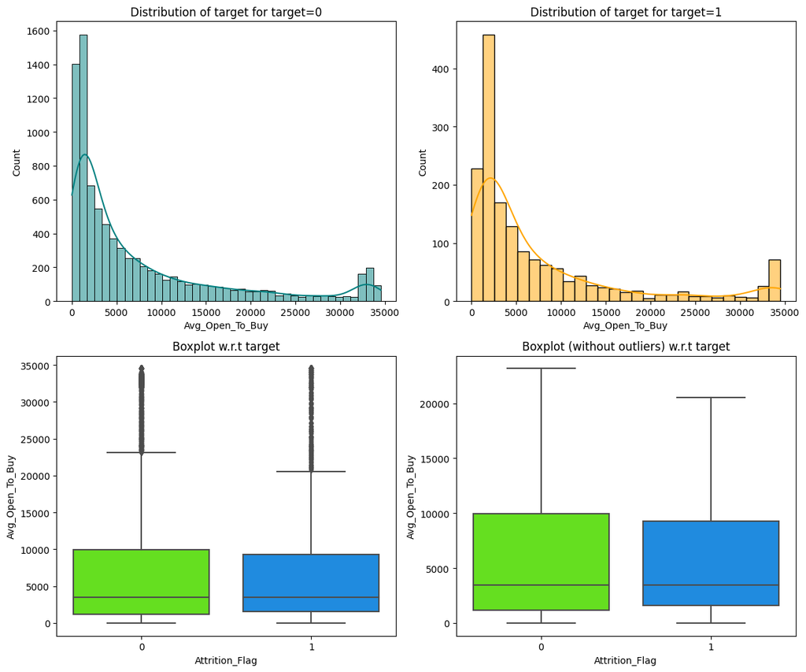

```python
distribution_plot_wrt_target(data, "Avg_Open_To_Buy", "Attrition_Flag")
```

```python
#data.head()
```

## Data Pre-processing

```python
Q1 = data.quantile(0.25)  # To find the 25th percentile
Q3 = data.quantile(0.75)  # To find the 75th percentile

IQR = Q3 - Q1  # Inter Quantile Range (75th perentile - 25th percentile)

# Finding lower and upper bounds for all values. All values outside these bounds are outliers
lower = (Q1 - 1.5 * IQR)
upper = (Q3 + 1.5 * IQR)
```

```python
# checking the % outliers
((data.select_dtypes(include=["float64", "int64"]) < lower) | (data.select_dtypes(include=["float64", "int64"]) > upper)).sum() / len(data) * 100
```

```
Attrition_Flag             16.066
Customer_Age                0.020
Dependent_count             0.000
Months_on_book              3.812
Total_Relationship_Count    0.000
Months_Inactive_12_mon      3.268
Contacts_Count_12_mon       6.211
Credit_Limit                9.717
Total_Revolving_Bal         0.000
Avg_Open_To_Buy             9.509
Total_Amt_Chng_Q4_Q1        3.910
Total_Trans_Amt             8.848
Total_Trans_Ct              0.020
Total_Ct_Chng_Q4_Q1         3.891
Avg_Utilization_Ratio       0.000
dtype: float64
```

```python
#create another copy of the dataframe
data1 = data.copy()
```

```python
data1["Income_Category"].unique()
```

```
array(['$60K - $80K', 'Less than $40K', '$80K - $120K', '$40K - $60K',
       '$120K +', 'abc'], dtype=object)
```

```python
data1["Income_Category"].replace("abc", np.nan, inplace=True) ### complete the code to replace the anomalous values with NaN
```

```python
data1.isna().sum()
```

```
Attrition_Flag                 0
Customer_Age                   0
Gender                         0
Dependent_count                0
Education_Level             1519
Marital_Status               749
Income_Category             1112
Card_Category                  0
Months_on_book                 0
Total_Relationship_Count       0
Months_Inactive_12_mon         0
Contacts_Count_12_mon          0
Credit_Limit                   0
Total_Revolving_Bal            0
Avg_Open_To_Buy                0
Total_Amt_Chng_Q4_Q1           0
Total_Trans_Amt                0
Total_Trans_Ct                 0
Total_Ct_Chng_Q4_Q1            0
Avg_Utilization_Ratio          0
dtype: int64
```

```python
# creating an instace of the imputer to be used
imputer = SimpleImputer(strategy="most_frequent")
```

```python
# Dividing train data into X and y

X = data1.drop(["Attrition_Flag"], axis=1)
y = data1["Attrition_Flag"]
```

```python
# Splitting data into training and validation set:

X_train, X_temp, y_train, y_temp = train_test_split(X,y,test_size=0.2,random_state=1)
X_test, X_val, y_test, y_val = train_test_split(X_temp, y_temp, test_size=0.25, random_state=1)

print(X_train.shape, X_val.shape, X_test.shape)
```

```
(8101, 19) (507, 19) (1519, 19)
```

## Missing value imputation

```python
reqd_col_for_impute = ["Education_Level", "Marital_Status", "Income_Category"]
```

```python
# Fit and transform the train data
X_train[reqd_col_for_impute] = imputer.fit_transform(X_train[reqd_col_for_impute])

# Transform the validation data
X_val[reqd_col_for_impute]  =  imputer.fit_transform(X_val[reqd_col_for_impute]) ## Complete the code to impute missing values in X_val

# Transform the test data
X_test[reqd_col_for_impute] = imputer.fit_transform(X_test[reqd_col_for_impute]) ## Complete the code to impute missing values in X_test
```

```python
#Let's do a sanity check and ensure no missing values
# Checking that no column has missing values in train or test sets
print(X_train.isna().sum())
print("-" * 30)
print(X_val.isna().sum())
print("-" * 30)
print(X_test.isna().sum())
```

```
Customer_Age                0
Gender                      0
Dependent_count             0
Education_Level             0
Marital_Status              0
Income_Category             0
Card_Category               0
Months_on_book              0
Total_Relationship_Count    0
Months_Inactive_12_mon      0
Contacts_Count_12_mon       0
Credit_Limit                0
Total_Revolving_Bal         0
Avg_Open_To_Buy             0
Total_Amt_Chng_Q4_Q1        0
Total_Trans_Amt             0
Total_Trans_Ct              0
Total_Ct_Chng_Q4_Q1         0
Avg_Utilization_Ratio       0
dtype: int64
------------------------------
Customer_Age                0
Gender                      0
Dependent_count             0
Education_Level             0
Marital_Status              0
Income_Category             0
Card_Category               0
Months_on_book              0
Total_Relationship_Count    0
Months_Inactive_12_mon      0
Contacts_Count_12_mon       0
Credit_Limit                0
Total_Revolving_Bal         0
Avg_Open_To_Buy             0
Total_Amt_Chng_Q4_Q1        0
Total_Trans_Amt             0
Total_Trans_Ct              0
Total_Ct_Chng_Q4_Q1         0
Avg_Utilization_Ratio       0
dtype: int64
------------------------------
Customer_Age                0
Gender                      0
Dependent_count             0
Education_Level             0
Marital_Status              0
Income_Category             0
Card_Category               0
Months_on_book              0
Total_Relationship_Count    0
Months_Inactive_12_mon      0
Contacts_Count_12_mon       0
Credit_Limit                0
Total_Revolving_Bal         0
Avg_Open_To_Buy             0
Total_Amt_Chng_Q4_Q1        0
Total_Trans_Amt             0
Total_Trans_Ct              0
Total_Ct_Chng_Q4_Q1         0
Avg_Utilization_Ratio       0
dtype: int64
```

```python
cols = X_train.select_dtypes(include=["object", "category"])
for i in cols.columns:
    print(X_train[i].value_counts())
    print("*" * 30)
```

```
F    4297
M    3804
Name: Gender, dtype: int64
Graduate         3703
High School      1601
Uneducated       1210
College           814
Post-Graduate     409
Doctorate         364
Name: Education_Level, dtype: int64
Married     4365
Single      3123
Divorced     613
Name: Marital_Status, dtype: int64
Less than $40K    3744
$40K - $60K       1437
$80K - $120K      1228
$60K - $80K       1114
$120K +            578
Name: Income_Category, dtype: int64
Blue        7534
Silver       461
Gold          88
Platinum      18
Name: Card_Category, dtype: int64
```

```python
cols = X_val.select_dtypes(include=["object", "category"])
for i in cols.columns:
    print(X_val[i].value_counts())
    print("*" * 30)
```

```
F    259
M    248
Name: Gender, dtype: int64
Graduate         246
High School      101
Uneducated        78
College           38
Post-Graduate     28
Doctorate         16
Name: Education_Level, dtype: int64
Married     292
Single      172
Divorced     43
Name: Marital_Status, dtype: int64
Less than $40K    222
$40K - $60K        91
$80K - $120K       80
$60K - $80K        77
$120K +            37
Name: Income_Category, dtype: int64
Blue        474
Silver       27
Gold          5
Platinum      1
Name: Card_Category, dtype: int64
```

```python
cols = X_test.select_dtypes(include=["object", "category"])
for i in cols.columns:
    print(X_train[i].value_counts())
    print("*" * 30)
```

```
F    4297
M    3804
Name: Gender, dtype: int64
Graduate         3703
High School      1601
Uneducated       1210
College           814
Post-Graduate     409
Doctorate         364
Name: Education_Level, dtype: int64
Married     4365
Single      3123
Divorced     613
Name: Marital_Status, dtype: int64
Less than $40K    3744
$40K - $60K       1437
$80K - $120K      1228
$60K - $80K       1114
$120K +            578
Name: Income_Category, dtype: int64
Blue        7534
Silver       461
Gold          88
Platinum      18
Name: Card_Category, dtype: int64
```

```python
X_train = pd.get_dummies(X_train, drop_first=True)
X_val = pd.get_dummies(X_val, drop_first=True)
X_test = pd.get_dummies(X_test, drop_first=True)
print(X_train.shape, X_val.shape, X_test.shape)
```

```
(8101, 29) (507, 29) (1519, 29)
```

After encoding, there are 29 column features

```python
# check the top 5 rows from the train dataset
X_train.head()
```

|  | Customer_Age | Dependent_count | Months_on_book | Total_Relationship_Count | Months_Inactive_12_mon | Contacts_Count_12_mon | Credit_Limit | Total_Revolving_Bal | Avg_Open_To_Buy | Total_Amt_Chng_Q4_Q1 | Total_Trans_Amt | Total_Trans_Ct | Total_Ct_Chng_Q4_Q1 | Avg_Utilization_Ratio | Gender_M | Education_Level_Doctorate | Education_Level_Graduate | Education_Level_High School | Education_Level_Post-Graduate | Education_Level_Uneducated | Marital_Status_Married | Marital_Status_Single | Income_Category_$40K - $60K | Income_Category_$60K - $80K | Income_Category_$80K - $120K | Income_Category_Less than $40K | Card_Category_Gold | Card_Category_Platinum | Card_Category_Silver |
| --- | --- | --- | --- | --- | --- | --- | --- | --- | --- | --- | --- | --- | --- | --- | --- | --- | --- | --- | --- | --- | --- | --- | --- | --- | --- | --- | --- | --- | --- |
| 6641 | 51 | 0 | 35 | 5 | 1 | 2 | 34516.000 | 2332 | 32184.000 | 0.800 | 4587 | 82 | 0.745 | 0.068 | 1 | 0 | 0 | 0 | 0 | 0 | 1 | 0 | 0 | 0 | 0 | 0 | 0 | 0 | 1 |
| 1302 | 56 | 3 | 36 | 6 | 3 | 3 | 34516.000 | 1047 | 33469.000 | 0.610 | 1378 | 30 | 0.429 | 0.030 | 1 | 0 | 0 | 0 | 0 | 1 | 1 | 0 | 0 | 0 | 0 | 0 | 0 | 0 | 0 |
| 5825 | 47 | 3 | 38 | 4 | 2 | 3 | 1438.300 | 0 | 1438.300 | 1.001 | 3511 | 64 | 0.882 | 0.000 | 0 | 0 | 1 | 0 | 0 | 0 | 0 | 1 | 0 | 0 | 0 | 1 | 0 | 0 | 0 |
| 1495 | 32 | 1 | 22 | 3 | 1 | 4 | 16912.000 | 1590 | 15322.000 | 1.274 | 2413 | 41 | 0.708 | 0.094 | 1 | 0 | 0 | 1 | 0 | 0 | 1 | 0 | 0 | 0 | 0 | 1 | 0 | 0 | 0 |
| 3342 | 50 | 3 | 39 | 5 | 3 | 4 | 13824.000 | 1582 | 12242.000 | 0.522 | 4630 | 74 | 0.644 | 0.114 | 1 | 0 | 1 | 0 | 0 | 0 | 1 | 0 | 0 | 0 | 1 | 0 | 0 | 0 | 0 |